[Explication de nombre de parametres de couches dans le resultat de model.summary()](https://stackoverflow.com/questions/36946671/keras-model-summary-result-understanding-the-of-parameters)

[Le rôle de biais dans les reseau de neurones](https://stackoverflow.com/questions/2480650/what-is-the-role-of-the-bias-in-neural-networks)

# **Les données**

Nous utiliserons des données provenant d'un ensemble de données Kaggle :

https://www.kaggle.com/harlfoxem/housesalesprediction

Colonnes Features (caractéristiques)

- **id** - ID unique pour chaque maison vendue
- **date** - Date de la vente de la maison
- **price** - Prix de chaque maison vendue
- **bedrooms** - Nombre de chambres
- **bathrooms** - Nombre de salles de bains, où 0,5 correspond à une chambre avec toilettes mais sans douche
- **sqft_living** - Superficie habitable
- **sqft_lot** - Superficie du terrain
- **floors** - Nombre d'étages
- **waterfront** - Une variable dummy (fictive) indiquant si l'appartement donnait sur le front de mer ou non
- **view** - Un indice de 0 à 4 de la qualité de la vue de la propriété condition - Un indice de 1 à 5 sur l'état de l'appartement
- **grade** - Un indice de 1 à 13, où 1-3 a un niveau de qualité faible de construction et de conception des bâtiments, 7 a un niveau moyen de construction et de conception, et 11-13 a un niveau de qualité élevé de construction et de conception
- **sqft_above** - La superficie de l'espace intérieur du logement qui est au-dessus du niveau du sol
- **sqft_basement** - La superficie de l'espace intérieur du logement qui se trouve sous le niveau du sol
- **yr_built** - L'année où la maison a été initialement construite
- **yr_renovated** - L'année de la dernière rénovation de la maison
- **zipcode** - Dans quelle zone de code postal se trouve la maison
- **lat** - Latitude
- **long** - Longitude
- **sqft_living15** - La superficie de l'espace intérieur de l'habitation pour les 15 voisins les plus proches
- **sqft_lot15** - La superficie du terrains des 15 voisins les plus proches

**Importer les librairies necessaires**

```python
import pandas as pd
import numpy as np
import matplotlib.pyplot as plt
import seaborn as sns
%matplotlib inline
```

**Importer le fichier csv**

Cet ensemble de données contient les prix de vente des maisons pour le comté de King, qui comprend Seattle. Il comprend les maisons vendues entre mai 2014 et mai 2015.

C'est un excellent ensemble de données pour évaluer des modèles de régression simples.

```python
df=pd.read_csv("kc_house_data.csv")
```

# **Analyse Exploratrice des données**

Premierement, essayons de voir si nous avons des données manquantes

```python
df.isnull().sum()
```

```
id               0
date             0
price            0
bedrooms         0
bathrooms        0
sqft_living      0
sqft_lot         0
floors           0
waterfront       0
view             0
condition        0
grade            0
sqft_above       0
sqft_basement    0
yr_built         0
yr_renovated     0
zipcode          0
lat              0
long             0
sqft_living15    0
sqft_lot15       0
dtype: int64
```

**Afficher la tete**

```python
df.head()
```

|  | id | date | price | bedrooms | bathrooms | sqft_living | sqft_lot | floors | waterfront | view | ... | grade | sqft_above | sqft_basement | yr_built | yr_renovated | zipcode | lat | long | sqft_living15 | sqft_lot15 |
| --- | --- | --- | --- | --- | --- | --- | --- | --- | --- | --- | --- | --- | --- | --- | --- | --- | --- | --- | --- | --- | --- |
| 0 | 7129300520 | 20141013T000000 | 221900.0 | 3 | 1.00 | 1180 | 5650 | 1.0 | 0 | 0 | ... | 7 | 1180 | 0 | 1955 | 0 | 98178 | 47.5112 | -122.257 | 1340 | 5650 |
| 1 | 6414100192 | 20141209T000000 | 538000.0 | 3 | 2.25 | 2570 | 7242 | 2.0 | 0 | 0 | ... | 7 | 2170 | 400 | 1951 | 1991 | 98125 | 47.7210 | -122.319 | 1690 | 7639 |
| 2 | 5631500400 | 20150225T000000 | 180000.0 | 2 | 1.00 | 770 | 10000 | 1.0 | 0 | 0 | ... | 6 | 770 | 0 | 1933 | 0 | 98028 | 47.7379 | -122.233 | 2720 | 8062 |
| 3 | 2487200875 | 20141209T000000 | 604000.0 | 4 | 3.00 | 1960 | 5000 | 1.0 | 0 | 0 | ... | 7 | 1050 | 910 | 1965 | 0 | 98136 | 47.5208 | -122.393 | 1360 | 5000 |
| 4 | 1954400510 | 20150218T000000 | 510000.0 | 3 | 2.00 | 1680 | 8080 | 1.0 | 0 | 0 | ... | 8 | 1680 | 0 | 1987 | 0 | 98074 | 47.6168 | -122.045 | 1800 | 7503 |

5 rows × 21 columns

**Quelques statistiques descriptives**

```python
df.describe().transpose()
```

|  | count | mean | std | min | 25% | 50% | 75% | max |
| --- | --- | --- | --- | --- | --- | --- | --- | --- |
| id | 21613.0 | 4.580302e+09 | 2.876566e+09 | 1.000102e+06 | 2.123049e+09 | 3.904930e+09 | 7.308900e+09 | 9.900000e+09 |
| price | 21613.0 | 5.400881e+05 | 3.671272e+05 | 7.500000e+04 | 3.219500e+05 | 4.500000e+05 | 6.450000e+05 | 7.700000e+06 |
| bedrooms | 21613.0 | 3.370842e+00 | 9.300618e-01 | 0.000000e+00 | 3.000000e+00 | 3.000000e+00 | 4.000000e+00 | 3.300000e+01 |
| bathrooms | 21613.0 | 2.114757e+00 | 7.701632e-01 | 0.000000e+00 | 1.750000e+00 | 2.250000e+00 | 2.500000e+00 | 8.000000e+00 |
| sqft_living | 21613.0 | 2.079900e+03 | 9.184409e+02 | 2.900000e+02 | 1.427000e+03 | 1.910000e+03 | 2.550000e+03 | 1.354000e+04 |
| sqft_lot | 21613.0 | 1.510697e+04 | 4.142051e+04 | 5.200000e+02 | 5.040000e+03 | 7.618000e+03 | 1.068800e+04 | 1.651359e+06 |
| floors | 21613.0 | 1.494309e+00 | 5.399889e-01 | 1.000000e+00 | 1.000000e+00 | 1.500000e+00 | 2.000000e+00 | 3.500000e+00 |
| waterfront | 21613.0 | 7.541757e-03 | 8.651720e-02 | 0.000000e+00 | 0.000000e+00 | 0.000000e+00 | 0.000000e+00 | 1.000000e+00 |
| view | 21613.0 | 2.343034e-01 | 7.663176e-01 | 0.000000e+00 | 0.000000e+00 | 0.000000e+00 | 0.000000e+00 | 4.000000e+00 |
| condition | 21613.0 | 3.409430e+00 | 6.507430e-01 | 1.000000e+00 | 3.000000e+00 | 3.000000e+00 | 4.000000e+00 | 5.000000e+00 |
| grade | 21613.0 | 7.656873e+00 | 1.175459e+00 | 1.000000e+00 | 7.000000e+00 | 7.000000e+00 | 8.000000e+00 | 1.300000e+01 |
| sqft_above | 21613.0 | 1.788391e+03 | 8.280910e+02 | 2.900000e+02 | 1.190000e+03 | 1.560000e+03 | 2.210000e+03 | 9.410000e+03 |
| sqft_basement | 21613.0 | 2.915090e+02 | 4.425750e+02 | 0.000000e+00 | 0.000000e+00 | 0.000000e+00 | 5.600000e+02 | 4.820000e+03 |
| yr_built | 21613.0 | 1.971005e+03 | 2.937341e+01 | 1.900000e+03 | 1.951000e+03 | 1.975000e+03 | 1.997000e+03 | 2.015000e+03 |
| yr_renovated | 21613.0 | 8.440226e+01 | 4.016792e+02 | 0.000000e+00 | 0.000000e+00 | 0.000000e+00 | 0.000000e+00 | 2.015000e+03 |
| zipcode | 21613.0 | 9.807794e+04 | 5.350503e+01 | 9.800100e+04 | 9.803300e+04 | 9.806500e+04 | 9.811800e+04 | 9.819900e+04 |
| lat | 21613.0 | 4.756005e+01 | 1.385637e-01 | 4.715590e+01 | 4.747100e+01 | 4.757180e+01 | 4.767800e+01 | 4.777760e+01 |
| long | 21613.0 | -1.222139e+02 | 1.408283e-01 | -1.225190e+02 | -1.223280e+02 | -1.222300e+02 | -1.221250e+02 | -1.213150e+02 |
| sqft_living15 | 21613.0 | 1.986552e+03 | 6.853913e+02 | 3.990000e+02 | 1.490000e+03 | 1.840000e+03 | 2.360000e+03 | 6.210000e+03 |
| sqft_lot15 | 21613.0 | 1.276846e+04 | 2.730418e+04 | 6.510000e+02 | 5.100000e+03 | 7.620000e+03 | 1.008300e+04 | 8.712000e+05 |

**Nous allons maintenant explorer un peu ces données en utilisant quelques techniques de visualistation de données.**

On remarque que la plus part de nos maisons tombent entre 0 et 1 millions de dollars et on peut avoir quelques valeurs extrêmes pour nos maisons vraiment très cheres. Il peut être bien de supprimer ces prix extrêmes de notre analyse, si elles ne representent qu'un faible nombre des points de données. Donc, on peut construire un modéle qui prédit de façon réaliste les prix de maisons pour des valeurs comprises entre 0 et 2 millions de dolllars. Si on supprime les prix extrêmes cela ne representra pas beaucoup des maoisons appparement sur le marché, les maisons valant plus de 3 millions de dollars sont toutes même assez rares. Si on veut construire un model pour une Agence Immobili2re.

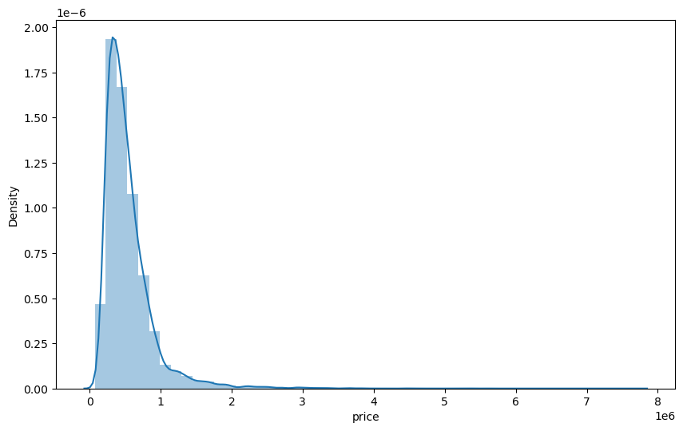

```python
plt.figure(figsize=(10, 6))
sns.distplot(df["price"])
```

**Afficher le nombre de chambres**

La majorité de maisons sont entre deux et cinq chambres. Il y a peut être une seule maison qui posede 33 chambres. C'est pourquoi la valeur apparait sur l'axe x mais cela ne montre pas de bare.

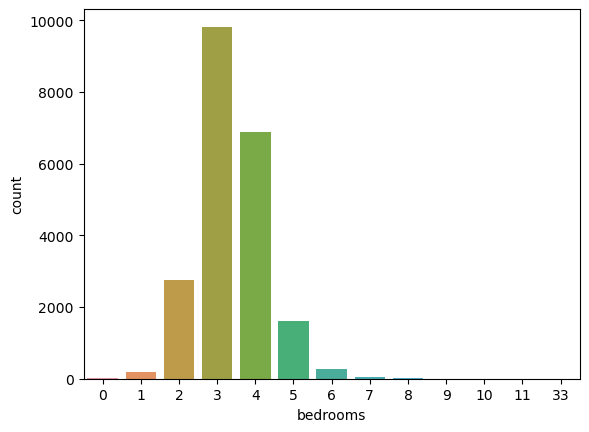

```python
sns.countplot(df["bedrooms"])
```

**Corrélation**

Constatons la corrélation. Et ensuite on peut voir ce qui est fortement correlé avec notre label (price) et nous trions par la suite avec sort_values pour voir ce qui est fortement correlé avec notre label. La surface habitable (sqft_living) semble trés corrélée avec les prix réels de maisons. Il faut alors exporer les varaibles très fortement corrélées avec notre label avec un graphique à nuage de points ou scaterplot

```python
df.corr()["price"].sort_values()
```

```
zipcode         -0.053203
id              -0.016762
long             0.021626
condition        0.036362
yr_built         0.054012
sqft_lot15       0.082447
sqft_lot         0.089661
yr_renovated     0.126434
floors           0.256794
waterfront       0.266369
lat              0.307003
bedrooms         0.308350
sqft_basement    0.323816
view             0.397293
bathrooms        0.525138
sqft_living15    0.585379
sqft_above       0.605567
grade            0.667434
sqft_living      0.702035
price            1.000000
Name: price, dtype: float64
```

**Faites un nuage de points**

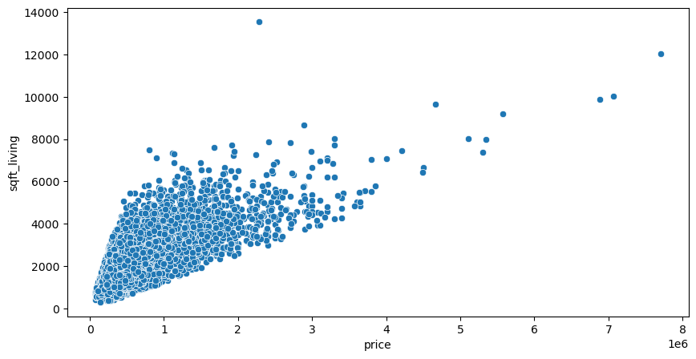

```python
plt.figure(figsize=(10, 5))
sns.scatterplot(x='price', y='sqft_living', data=df)
```

**Boxplot**

Boxplot de la distribution de prix par nombre de chambres. Il y a une grande variation entre 3 et 7 chambres. Et c'est ce qui correspond à notre graphique de comptage. Cela explique donc pourquoi il y a une grande variation dans les prix entre 3 et 7 chambres

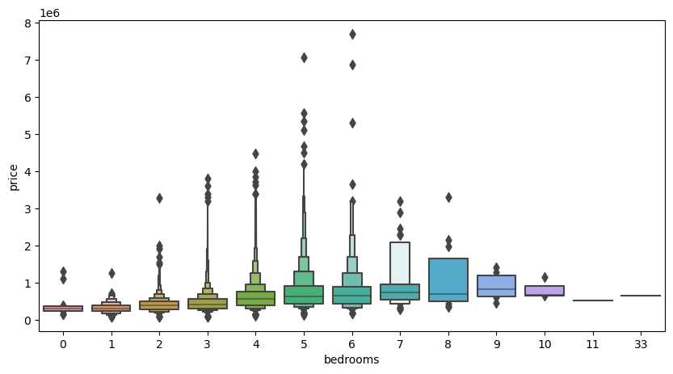

```python
plt.figure(figsize=(10,5))
sns.boxenplot(x="bedrooms", y="price", data=df)
```

Il semble avoir une distribution de prix pour la longititude -122.2. Cela semble donc à une zone de maison qui coûte assez chère. On peut voir très clairement la distribution tout long du prix

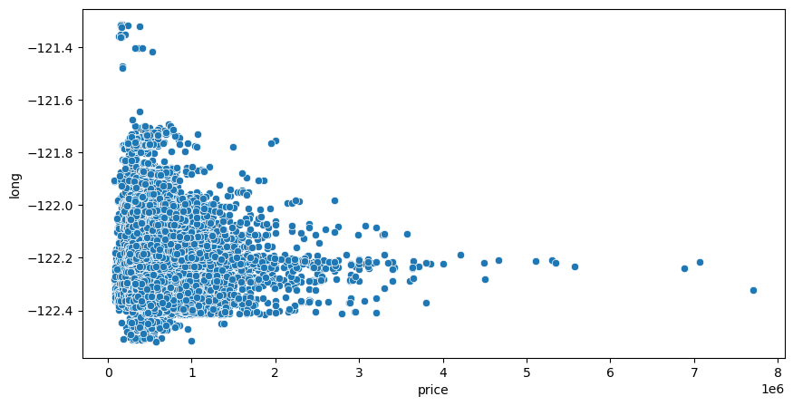

```python
plt.figure(figsize=(10,5))
sns.scatterplot(x="price", y="long", data=df)
```

Le même comprtement que précédement semble se produire, il y a une zone de maisons assez chères

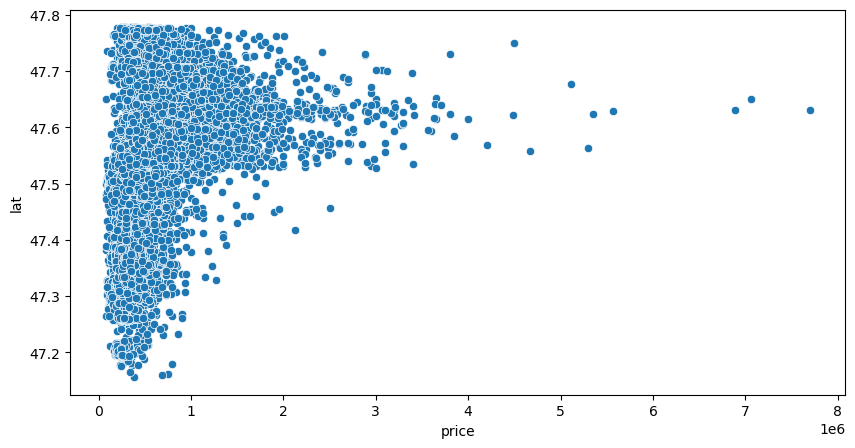

```python
plt.figure(figsize=(10,5))
sns.scatterplot(x="price", y="lat", data=df)
```

Cela colore de plus ou moins foncée en fonction de prix. Très claire si le prix est faible et très focné si le prix est elevé. Et on remarque une zone plus foncée qui semble correspondre à la longititude de -122.2 et latitude entre 47.6 et 47.7. On va nettoyer cette carte en retirant les valeurs extrêmes et donc les prix très élevés.

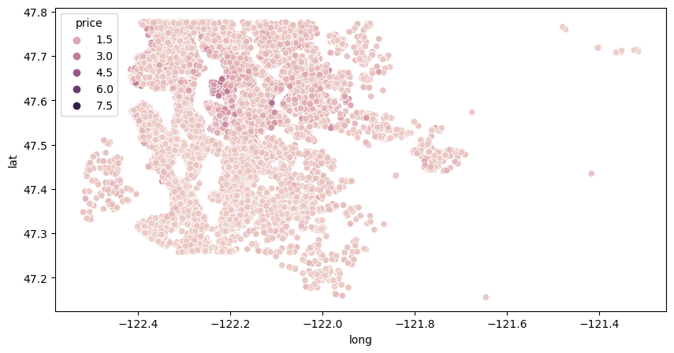

```python
plt.figure(figsize=(10,5))
sns.scatterplot(x="long", y="lat", data=df, hue="price")
```

Trier sur la variable price et regarder les 20 maisons les plus chères

```python
df.sort_values("price", ascending=False).head(20)
```

|  | id | date | price | bedrooms | bathrooms | sqft_living | sqft_lot | floors | waterfront | view | ... | grade | sqft_above | sqft_basement | yr_built | yr_renovated | zipcode | lat | long | sqft_living15 | sqft_lot15 |
| --- | --- | --- | --- | --- | --- | --- | --- | --- | --- | --- | --- | --- | --- | --- | --- | --- | --- | --- | --- | --- | --- |
| 7252 | 6762700020 | 20141013T000000 | 7700000.0 | 6 | 8.00 | 12050 | 27600 | 2.5 | 0 | 3 | ... | 13 | 8570 | 3480 | 1910 | 1987 | 98102 | 47.6298 | -122.323 | 3940 | 8800 |
| 3914 | 9808700762 | 20140611T000000 | 7062500.0 | 5 | 4.50 | 10040 | 37325 | 2.0 | 1 | 2 | ... | 11 | 7680 | 2360 | 1940 | 2001 | 98004 | 47.6500 | -122.214 | 3930 | 25449 |
| 9254 | 9208900037 | 20140919T000000 | 6885000.0 | 6 | 7.75 | 9890 | 31374 | 2.0 | 0 | 4 | ... | 13 | 8860 | 1030 | 2001 | 0 | 98039 | 47.6305 | -122.240 | 4540 | 42730 |
| 4411 | 2470100110 | 20140804T000000 | 5570000.0 | 5 | 5.75 | 9200 | 35069 | 2.0 | 0 | 0 | ... | 13 | 6200 | 3000 | 2001 | 0 | 98039 | 47.6289 | -122.233 | 3560 | 24345 |
| 1448 | 8907500070 | 20150413T000000 | 5350000.0 | 5 | 5.00 | 8000 | 23985 | 2.0 | 0 | 4 | ... | 12 | 6720 | 1280 | 2009 | 0 | 98004 | 47.6232 | -122.220 | 4600 | 21750 |
| 1315 | 7558700030 | 20150413T000000 | 5300000.0 | 6 | 6.00 | 7390 | 24829 | 2.0 | 1 | 4 | ... | 12 | 5000 | 2390 | 1991 | 0 | 98040 | 47.5631 | -122.210 | 4320 | 24619 |
| 1164 | 1247600105 | 20141020T000000 | 5110800.0 | 5 | 5.25 | 8010 | 45517 | 2.0 | 1 | 4 | ... | 12 | 5990 | 2020 | 1999 | 0 | 98033 | 47.6767 | -122.211 | 3430 | 26788 |
| 8092 | 1924059029 | 20140617T000000 | 4668000.0 | 5 | 6.75 | 9640 | 13068 | 1.0 | 1 | 4 | ... | 12 | 4820 | 4820 | 1983 | 2009 | 98040 | 47.5570 | -122.210 | 3270 | 10454 |
| 2626 | 7738500731 | 20140815T000000 | 4500000.0 | 5 | 5.50 | 6640 | 40014 | 2.0 | 1 | 4 | ... | 12 | 6350 | 290 | 2004 | 0 | 98155 | 47.7493 | -122.280 | 3030 | 23408 |
| 8638 | 3835500195 | 20140618T000000 | 4489000.0 | 4 | 3.00 | 6430 | 27517 | 2.0 | 0 | 0 | ... | 12 | 6430 | 0 | 2001 | 0 | 98004 | 47.6208 | -122.219 | 3720 | 14592 |
| 12370 | 6065300370 | 20150506T000000 | 4208000.0 | 5 | 6.00 | 7440 | 21540 | 2.0 | 0 | 0 | ... | 12 | 5550 | 1890 | 2003 | 0 | 98006 | 47.5692 | -122.189 | 4740 | 19329 |
| 4149 | 6447300265 | 20141014T000000 | 4000000.0 | 4 | 5.50 | 7080 | 16573 | 2.0 | 0 | 0 | ... | 12 | 5760 | 1320 | 2008 | 0 | 98039 | 47.6151 | -122.224 | 3140 | 15996 |
| 2085 | 8106100105 | 20141114T000000 | 3850000.0 | 4 | 4.25 | 5770 | 21300 | 2.0 | 1 | 4 | ... | 11 | 5770 | 0 | 1980 | 0 | 98040 | 47.5850 | -122.222 | 4620 | 22748 |
| 19017 | 2303900100 | 20140911T000000 | 3800000.0 | 3 | 4.25 | 5510 | 35000 | 2.0 | 0 | 4 | ... | 13 | 4910 | 600 | 1997 | 0 | 98177 | 47.7296 | -122.370 | 3430 | 45302 |
| 7035 | 853200010 | 20140701T000000 | 3800000.0 | 5 | 5.50 | 7050 | 42840 | 1.0 | 0 | 2 | ... | 13 | 4320 | 2730 | 1978 | 0 | 98004 | 47.6229 | -122.220 | 5070 | 20570 |
| 16302 | 7397300170 | 20140530T000000 | 3710000.0 | 4 | 3.50 | 5550 | 28078 | 2.0 | 0 | 2 | ... | 12 | 3350 | 2200 | 2000 | 0 | 98039 | 47.6395 | -122.234 | 2980 | 19602 |
| 6508 | 4217402115 | 20150421T000000 | 3650000.0 | 6 | 4.75 | 5480 | 19401 | 1.5 | 1 | 4 | ... | 11 | 3910 | 1570 | 1936 | 0 | 98105 | 47.6515 | -122.277 | 3510 | 15810 |
| 18482 | 4389201095 | 20150511T000000 | 3650000.0 | 5 | 3.75 | 5020 | 8694 | 2.0 | 0 | 1 | ... | 12 | 3970 | 1050 | 2007 | 0 | 98004 | 47.6146 | -122.213 | 4190 | 11275 |
| 15255 | 2425049063 | 20140911T000000 | 3640900.0 | 4 | 3.25 | 4830 | 22257 | 2.0 | 1 | 4 | ... | 11 | 4830 | 0 | 1990 | 0 | 98039 | 47.6409 | -122.241 | 3820 | 25582 |
| 19148 | 3625049042 | 20141011T000000 | 3635000.0 | 5 | 6.00 | 5490 | 19897 | 2.0 | 0 | 0 | ... | 12 | 5490 | 0 | 2005 | 0 | 98039 | 47.6165 | -122.236 | 2910 | 17600 |

20 rows × 21 columns

```python
non_top_1_perc=df.sort_values("price", ascending=False).iloc[216:]
```

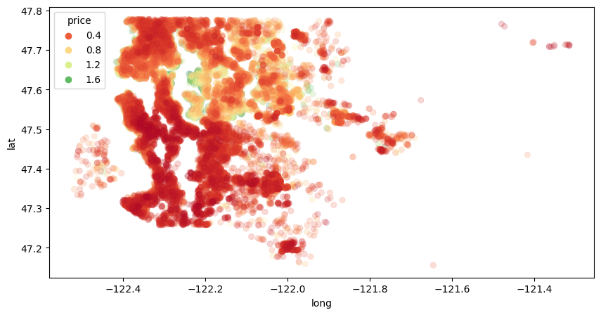

```python
plt.figure(figsize=(10,5))
sns.scatterplot(x="long", y="lat", data=non_top_1_perc, hue="price", edgecolor=None, alpha=0.2, palette="RdYlGn")
```

On peut voir la distribution des prix si oui ou non la maison est en bord de mer ou d'un point d'eau. Et donc, clairement, il semble que si vous êtes en bord de mer donc la valeur de classe 1, vous êtes plus susceptible d'être vendue à un prix plus important et ce qui est assez logique en fait.

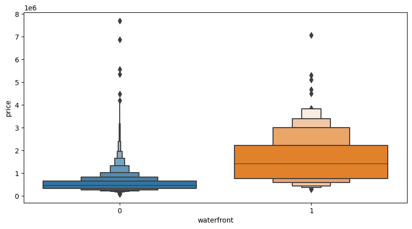

```python
plt.figure(figsize=(10,5))
sns.boxenplot(x="waterfront", y="price", data=df)
```

## *Etape de feature engenering ou ingenerie des caracteristiques*

Cette étape permet de se débrasser des caractéristiques qui ne sont pas utiles à la construction du modéle ou encore permet de créer de nouvelles caractéristiques qui seront utiles.

Supprimons la variable id

```python
df=df.drop("id", axis=1)
```

Regardons la colone date. Cela ressemble à une chaine de caractère. Donc, on peut la convertir en objet de type datetime

```python
df["date"]=pd.to_datetime(df["date"])
```

```python
df["date"]
```

```
0       2014-10-13
1       2014-12-09
2       2015-02-25
3       2014-12-09
4       2015-02-18
           ...
21608   2014-05-21
21609   2015-02-23
21610   2014-06-23
21611   2015-01-16
21612   2014-10-15
Name: date, Length: 21613, dtype: datetime64[ns]
```

L'option lambda c'est un racourci pour une fonction, ça évite de la définir et d'utiliser de la memoire pour sa définition, mais c'est l'equivlent de ce qui suit :

*df year_extraction(date) return date.year*

```python
df["year"]=df["date"].apply(lambda date:date.year)
```

```python
df["month"]=df["date"].apply(lambda date:date.month)
```

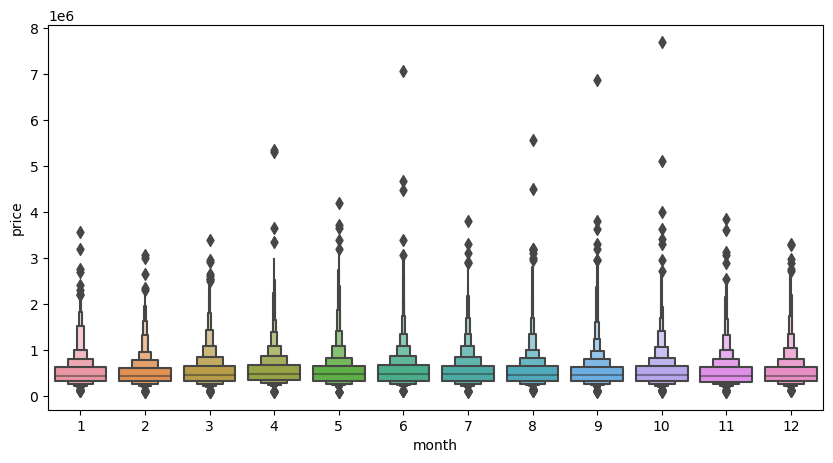

```python
plt.figure(figsize=(10,5))
sns.boxenplot(x="month", y="price", data=df)
```

C'est compliquer à partir de ce graphique de dire si oui ou non il y a de différence significative dans la distribution entre les différents moi où vous allez vendre votre maison. Dans ce cas c'est peut être plus parlant de voir le nombre. Pour cela, on va taper à la suite

Nous avons groupé par mois puis on a pris la moyenne et on explore les prix. Et là on peut voir s'il y a des différences significatives entre les mois pour l'observer visulement, on peut aussi utiliser plot sur le groupby. Et donc, cela nous montre le comprtement, il semble donc y avoir des différences entre les mois, cela va de 510000 dollars à 560000 dollars en moyenne. Donc, pas une énorme différence dans le prix mais il semble tout même que y a une tendance en fonction de mois de ventes. On peut faire la même chose pour l'année.

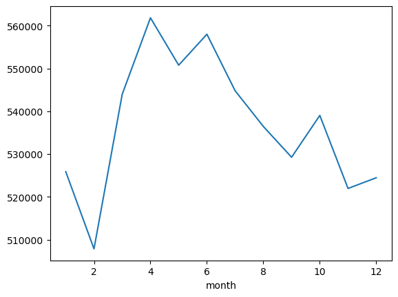

```python
df.groupby("month").mean()["price"].plot()
```

Là c'est très logique parce que dans cette région les prix augmentent au fur et en mesure que les années passent. Cela s'explique notmment par l'inflation naturelle de l'immoblier. Donc, on a fait du feature engenering ce qui a abouti à la création de deux nouvlles caractéristiques l'année et le mois

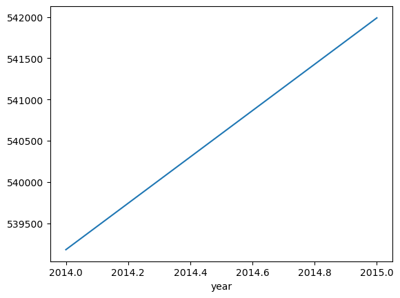

```python
df.groupby("year").mean()["price"].plot()
```

On supprime maintenant la variable date, elle n'est plus utile parce qu'on a extrait d'elle le mois et l'année

```python
df=df.drop("date", axis=1)
```

On va avoir une idée sur le nombre de zipcodes uniques et de leur distribution des valeurs dans le dataset. Il semble donc, on a 70 codes uniques. Et c'est probabmlement trop pour créer des variables demmies à partir de cette caractéristique. On va alors supprimer cette colonne qui peut avoir 7o demmies.

```python
df["zipcode"].value_counts()
```

```
98103    602
98038    590
98115    583
98052    574
98117    553
        ...
98102    105
98010    100
98024     81
98148     57
98039     50
Name: zipcode, Length: 70, dtype: int64
```

```python
df=df.drop("zipcode", axis=1)
```

Regardons maintenant la variable yr_renovated. On constate que la plus part de valeurs de cette variable sont de zéros signifiant simplement que la masion n'a jamais été renovée. Par ailleurs, plus la rénovation de maisons est recente mieux c'est

```python
df["yr_renovated"].value_counts()
```

```
0       20699
2014       91
2013       37
2003       36
2005       35
        ...
1951        1
1959        1
1948        1
1954        1
1944        1
Name: yr_renovated, Length: 70, dtype: int64
```

## *Etape de pre-traitement et de création de notre model*

Mettre les données à l'échelle, diviser les données en un set d'entrainement et en un set de test de construire notre modéle. Si on ajoute 'value' cela retourne en sortie ci-dessous de tableaux numpy

Separer nos caracteristiques de nos labels

```python
X=df.drop("price", axis=1).values
y=df["price"].values
```

**Faisons maintenant la repartition entre entrainement et test**

```python
from sklearn.model_selection import train_test_split
```

```python
X_train, X_test, y_train, y_test = train_test_split(X, y, test_size=0.3, random_state=101)
```

```python
y_train.shape
```

```
(15129,)
```

On vient de faire la répartition des données. maintenant, il est temps d'éffectuer la mise en échelle ou le skling. On fait le skling après avoir fait la répartion entrainement et en test de nos données. Parce que la mise en échelle sera adaptée à nos données d'entrainment seulement pour eviter toute fuite de données depuis le set de test

```python
from sklearn.preprocessing import MinMaxScaler
```

```python
scaler=MinMaxScaler()
```

On va gagner du temps en adaptant et en transformant tout notre set d'entrainement en une seule étape avec la méthode suivante :

```python
X_train=scaler.fit_transform(X_train)
```

```python
X_test=scaler.transform(X_test)
```

**Etape de construction du model**

```python
from tensorflow.keras.models import Sequential
from tensorflow.keras.layers import Dense
```

On va essayer d'accorder les nombres de neuronnes ou units dans notre couche à partir de la taille de données X des caracteristiques. Pour cela on va regarder la forme de nos données X. Et on constate qu'on a 19 caractéristiques d'entrée et donc, c'est sans doute c'est sans doute une bonne chose, d'avoir 19 neuronnes dans notre couche.

```python
X_train.shape
```

```
(15129, 19)
```

```python
Model = Sequential()

Model.add(Dense(19, activation='relu'))
Model.add(Dense(19, activation='relu'))
Model.add(Dense(19, activation='relu'))
Model.add(Dense(19, activation='relu'))

Model.add(Dense(1))

Model.compile(optimizer="adam", loss="mse")
```

On va éxecuter l'entrainement. Ici, on entraine sur X_train et sur y_train et aucour de cet entrainement, on vérifie ou on contrôle sur notre set de test avec ce paramétre validation_data, et cela nous donnera de supers graphiques pour savoir si oui ou non on a un overfiting. Donc, nous allons nourir ou alimenter nos données par batch des données d'entrainement ou par lot de données. Pour cela on appelle à la suite batch_zise. C'est plus frequent de prendre de puissance de 2 pour la taille du batch (64, 128, 256, etc). Et plus la taille du bacht est petit, plus lourd sera l'entrainement mais vous serez moins susceptible de surapprendre ou d'avoir de l'overfiting parce que nous ne passons pas tout notre ensemble des données en une fois

```python
Model.fit(x=X_train, y=y_train, validation_data=(X_test, y_test), batch_size=128, epochs=400)
```

```
<keras.callbacks.History at 0x232b0463430>
```

**Explorer l'evaluation sur les données de test et aussi utiliser ce model pour predire un prix à partir de toutes nouvelles données**

On va explorer à quoi ressemble l'historique de perte de notre modéle. loss est notre perte sur le modéle et val_loss est notre perte sur nos données de validation

```python
losses=pd.DataFrame(Model.history.history)
```

On peut directement comparer le comportement de notre perte d'entrainement donc ici en bleue versus la perte de validation en orange. C'est exactement, le genre de signal que l'on veut avec une décroissance à la fois pour la perte de l'entrainement et pour la perte du test. Et ensuite, il n'y a pas d'augmentation de la perte du set de validaton, cela signifie que techniquement on aurait pu continuer à entrainer. Si on voit cette ligne orange faire un pic après quelques epochs et continuer à augmenter. Cela signifie que nous sommes en overfiting ou surapprentissage de données d'entrainement. Et c'est caracterisé par une bien plus grande perte sur notre ensemble de validation ou test. Dans notre cas, c'est le comportement parfait que nous avons envie de voir. Nous voulons voir la perte d'entrainement et de validation diminuer et continuer cette décroissance ensemble indiquant alors aucun overfiting ici.

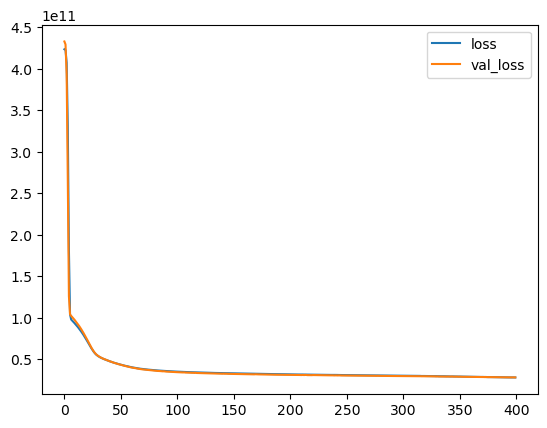

```python
losses.plot()
```

**Faisons quelques évaluations sur notre set de test**

```python
from sklearn.metrics import mean_squared_error, mean_absolute_error, explained_variance_score
```

```python
predictions=Model.predict(X_test)
```

```python
predictions
```

```
array([[ 487763.03],
       [ 632247.4 ],
       [ 544494.75],
       ...,
       [ 406503.78],
       [ 215600.77],
       [1010892.6 ]], dtype=float32)
```

**On va comparer ces predictions aux valeurs de prix réels**

Voici notre erreur quadratique moyenne.

```python
mean_squared_error(y_test, predictions)
```

```
27768978079.332733
```

C'est une trés grande valeur mais ce n'est pas inquietant parce qu'on traite le prix d'une maison. C'est delicat à intrepréter comme valeur puisque l'unité est du dollar au carré, on peut donc prendre la racine carrée de cela.

```python
np.sqrt(mean_squared_error(y_test, predictions))
```

```
166640.2654802636
```

```python
mean_absolute_error(y_test, predictions)
```

```
103227.94875968731
```

```python
df["price"].describe()
```

```
count    2.161300e+04
mean     5.400881e+05
std      3.671272e+05
min      7.500000e+04
25%      3.219500e+05
50%      4.500000e+05
75%      6.450000e+05
max      7.700000e+06
Name: price, dtype: float64
```

```python
explained_variance_score(y_test, predictions)
```

```
0.8021766985473168
```

Cette ligne rouge répresente la prédiction parfaite. On remarque notre modéle est puni par quelques valeurs abérantes qui sont finalement de prix extrêmes de maisons assez chères. Et on n'est pas bon pour prédire ces maisons qui valent plusieurs millions de dollars. Par contre, on est plutot bon, du moins pas mauvais pour prédire des maisons dont le prix se situent entre 0 et 2 millions de dollars. On constate une bonne correspondance entre nos données test et nos prédictions sur cette portion du graphique entre 0 et 2 millions. Et c'est essentiellemet cette information que la mesure variance score rapporte avec le nombre ou valeur 0.80. Cela pourrait valoir le coup de réentrainer notre modéle non plus sur le dataframe complet mais sur 99% du datframe en retirant les maisons le plus cheres. Ainsi, on aura tendance à dire en cas d'une maison qui vaut plus de 3 millions, desolé mais notre modéle n'est pas assez bon pour ce genre de maisons. Cela dépend du contexte et à quelle question, vous devez répondre et quel probléme vous essayez de résoudre

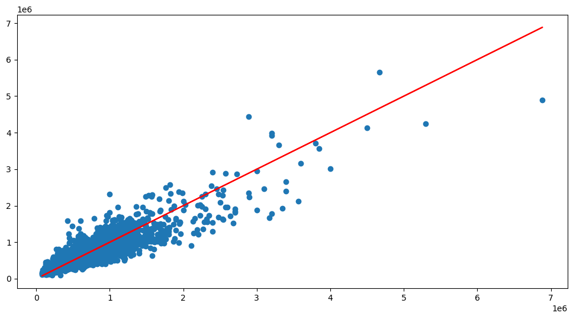

```python
plt.figure(figsize=(12,6))
plt.scatter(y_test, predictions)

plt.plot(y_test, y_test, 'r')
```

Comment utiliser notre modéle pour prédire toute une nouvelle maison

Le code suivant donne seulement les caractéristiques d'une maison

```python
single_house=df.drop("price", axis=1).iloc[0]
```

La premiére étape c'est de mettre ces données à la même échelle que les données d'entrainement et de test

C'est un tableau numpy mais le shape est un incorrect, il y a qu'un seul crochet. On va le reshape. On a cette fois-ci bien le double crochets de dimension deux. Alors -1 signifie prend le nombres de lignes possibles pour avoir 19 colonnes par rapport aux nombres de valeurs du tableau. Maintenant qu'il est dans une forme ou dimensuion corrécte, on va le mettre en échelle.

```python
single_house.values.reshape(-1,19)
```

```
array([[ 3.00000e+00,  1.00000e+00,  1.18000e+03,  5.65000e+03,
         1.00000e+00,  0.00000e+00,  0.00000e+00,  3.00000e+00,
         7.00000e+00,  1.18000e+03,  0.00000e+00,  1.95500e+03,
         0.00000e+00,  4.75112e+01, -1.22257e+02,  1.34000e+03,
         5.65000e+03,  2.01400e+03,  1.00000e+01]])
```

```python
single_house=scaler.transform(single_house.values.reshape(-1,19))
```

Maintenant, on a plus qu'à utiliser le modéle et prédire en passant cette nouvelle masion.

```python
Model.predict(single_house)
```

```
array([[285587.2]], dtype=float32)
```